# Reference construction Bullsharks

```r
source("scr/libraries.R")
```

```
Failed to query server: Connection timed out
```

```r
source("scr/ggplot.R")
source("scr/xtrafunctions.R")
```

# Sequence data

## MiSeq library for reference construction

### Demultiplex CLE-1

Use `demultiplex.pl` script to write bash script to wrap `process_radtags`. Edit file to only use one cut site (sphI) to parse reads.

### Demultiplex stats

Parse process radtags log file

```r
# number of samples in index
n_samples <- 20
index <- "CGATGT"
species <- "CLE"
# read in summary per barcode
log <- read_table2("data/SEQ/CLE-1_CGATGT_radtags.log",
            skip = 13, n_max = n_samples,
            col_names = c("BARCODE", "TOTAL_READS", "AMBIG_READS", "LQ_READS", "RETAINED")) %>%
  mutate(PROP_RETAINED = RETAINED/TOTAL_READS,
         INDEX = index,
         SPECIES = species) %>%
  select(SPECIES, INDEX, BARCODE, PROP_RETAINED, TOTAL_READS, RETAINED, AMBIG_READS, LQ_READS)
```

```
Error: 'data/SEQ/CLE-1_CGATGT_radtags.log' does not exist in current working directory ('/home/soleary/BULLSHARKS/CLE_POPGEN').
```

Plot distributions of total and proportion of retained reads.

```r
log %>%
  select(INDEX, BARCODE, PROP_RETAINED, TOTAL_READS) %>%
  gather(key = STAT, value = READS, 3:4) %>%
  ggplot(aes(x = READS)) +
  geom_histogram(color = "black", fill = "darkorange") +
  labs(x = "reads") +
  facet_grid(. ~ STAT, scales = "free") +
  theme_standard
```

[output not shown]

# Quality trimming & initial reference assembly in dDocent pipeline

Sequences of MiSeq and HiSeq libraries only need be quality trimmed once, this can be done in the `dDocent` pipeline before mapping.

# Initial assembly

## Run dDocent for preliminary data

Execute `dDocent` from within MiSeq Library folder (`data/SEQ/CLE-1`) containing demultiplexed files and run initial assembly (parameter `OL` for overlapping reads) for c = 0.8 (lowest possible value) and K1 and K2 = 2.

The number of reads (contigs) contained in the reference depends on the data-cutoffs:

- minimum within individual coverage **K1** (i.e. read must occur at least K1 times within an individual to be retained).
- minimum number of individuals a read must occur in to be included **K2**.
- % similarity for two stacks to be collapsed into one locus **c**.

## Distribution of within individuals unique reads

During reference assembly dDocent creates a file `uniqseq.data` containing the number of unique reads with 2X, 3X… coverage. dDocent will plot the distribution to aid in choosing a cut-off value.

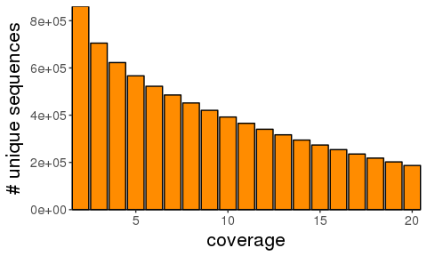

```r
uniqseq_loci <- read.csv("data/REF/uniqseq.data", sep="", header = FALSE,
                         col.names = c("COVERAGE", "N_READS"))
ggplot(uniqseq_loci, aes(x = COVERAGE, y = N_READS)) +
  geom_bar(stat="identity", color = "black", fill = "darkorange") +
  scale_x_continuous(expand=c(0,0)) +
  scale_y_continuous(expand=c(0,0)) +
  labs(x = "coverage", y = "# unique sequences") +
  theme_standard
```

## Distribution of between individuals unique reads

In addition, dDocent creates the file `uniqseq.peri.data` which contains the number of unique sequences that occur in more than X individuals. By choosing a cut-off value the user determines in how many individuals a unique sequence must occur in order for it to be included in the reference. In initial value of approx. 10% of individuals is sufficient for intial reference construction.

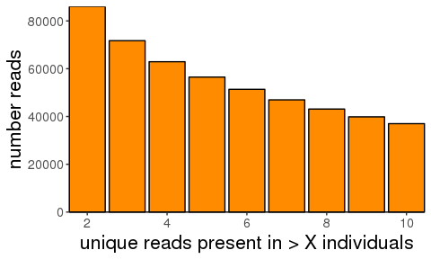

```r
uniqseq_ind <- read.csv("data/REF/uniqseq.peri.data", sep="", header = FALSE,
                        col.names = c("N_IND", "N_READS"))
ggplot(uniqseq_ind, aes(x = N_IND, y = N_READS)) +
  geom_bar(stat="identity", color = "black", fill = "darkorange") +
  scale_x_continuous(expand=c(0,0)) +
  scale_y_continuous(expand=c(0,0)) +
  labs(x = "unique reads present in > X individuals",
       y = "number reads") +
  theme_standard
```

dDocent will generate a `fasta`-file containing all the loci included in the reference based on the chosen parameters. After initial reference construction, references for combinations of c, K1 and K2 should be generated and compared in terms of the number of loci and the quality of read mapping for individuals to be included in the data analysis.

# Optimize assembly parameters (c, K1 & K2)

## Choose c parameter

### Run `RefOpt`-Script

`RefOpt` used to create separate references at each similarity value (c = 0.8 - 0.98) for a given range of K1 = 1-10 (cut-off for within individual coverage) and K2 = 1-10 (minimum no. of individual read must occur in).

Before running dDocent ensure that `uniq.seq`-files (generated during intial dDocent run to create reference) are in same directory as reference optimizing script being executed from. Specificy `minK1`, `maxK1`, `minK2`, `maxK2`, `Assenmbly type` and `number of processors.

Output file `kopt.data` contains the number of reads in reference for each c, K1, K2 combination.

### Analyze `kopt`-output file

```r
# import output from RefOpt2.sh script
kopt <- read.table("data/REF/kopt.data", sep="", header = FALSE,
                   col.names = c("K1", "K2", "c", "N_CONTIGS"))
```

The number of reads in the reference vary depending on the minimum within individual coverage (K1) for each K2 for c = 0.8 - 0.98. The number of reads in the reference decrease as the cut-off for minimum within individual coverage for loci to be included increase. For each value of K1 the number of reads in the reference decreases as the minimum number of individuals a locus must be recovered in to be included increases. The number of loci included in a reference increases with c - for lower values of K1 and K2 there is a sudden increase in loci around c = 0.9 indicating that loci are being oversplit.

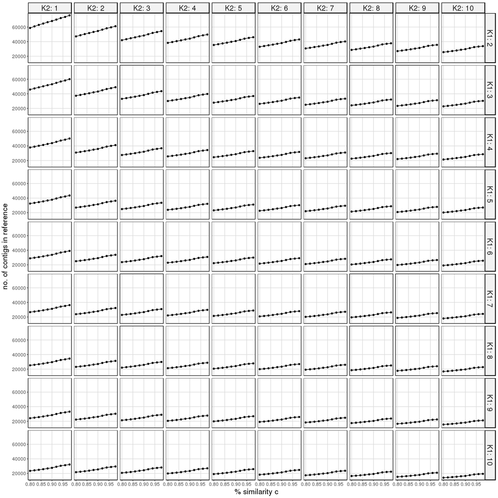

```r
# plot number of reads for each value of c for each K1 and K2 combination
ggplot(kopt, aes(x = c, y = N_CONTIGS)) +
  geom_point() +
  geom_line() +
  facet_grid(K1 ~ K2, labeller=label_both) +
  labs(x = "% similarity c", y = "no. of contigs in reference") +
  theme_facet
```

For K2 = 2, reads must occur in at least ~10% of individuals used to create the reference to be included.

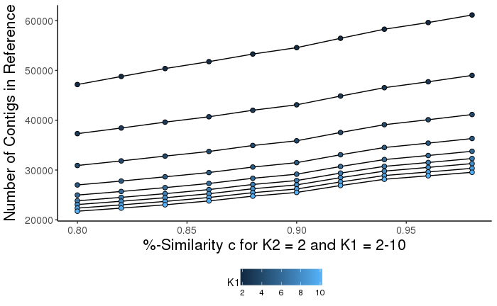

```r
# plot no. of reads vs. c for K2 = 2 K1 = 2-10
ggplot(kopt, aes(x = c, y = N_CONTIGS, fill = K1)) +
  geom_line(data = subset(kopt, K2 %in% 2), aes(group = K1), color = "black") +
  geom_point(data = subset(kopt, K2 %in% 2),
             shape = 21, size = 2, color = "black") +
  labs(x = "%-Similarity c for K2 = 2 and K1 = 2-10",
       y = "Number of Contigs in Reference") +
  theme_standard
```

The lower the cut-off values from K1 and K2, the more likely loci will be included that are due to individual variability and are not informative on a population level (which can unnecessarily increase computational time).

If the cut-off values are too high loci that are informative might be excluded, which could lead to ascertainment bias. The optimum values for K1 and K2 are best determined by analyzing the mapping statistics of individuals mapped to references created for a combination of K1 and K2 values after an optimum c-value has been determined. The user will be able to compare the number of reads mapped in general, the number of reads mapped in pairs, the number of unmapped reads and the distribution of coverage to determine the best combinations of K.

c-parameter chosen based on `kopt.data` results: **c = 0.8**

## Choose K1 and K2 cut-off values

### Optimize with MiSeq data only

#### Run RefMapOpt

For c = 0.8, map MiSeq reads to reference for K1 = 1 - 10 and K2 = 1 - 10 and outputs summary in `mapping.results`.

Compare mapping quality across different combinations of K1 and K2 for c = 0.8.

```r
mapstats <- read_table2("data/SEQ/CLE-1/mapping.results") %>%
  unite(REF, K1, K2, sep = "", remove = FALSE)
```

### Evaluate & compare mapping results

Number of loci in the reference and the mean number of reads mapped per individual decrease for increasingly high cut-off values.

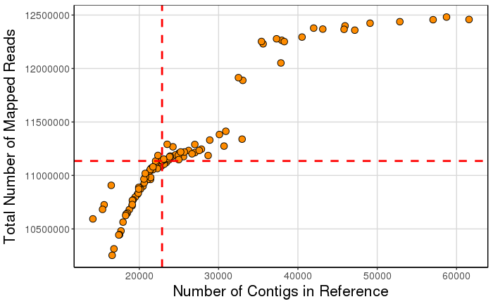

```r
# calculate 95th quantile
mapped <- unname(quantile(mapstats$SUM_Mapped, c(0.5)))
lociref <- unname(quantile(mapstats$Contigs, c(0.5)))
# plot no of contigs in ref vs sum mapped reads
ggplot(mapstats, aes(x = Contigs, y = SUM_Mapped)) +
  geom_point(shape = 21, size = 3, color = "black", fill = "darkorange") +
  geom_vline(aes(xintercept = lociref),
               color = "red", linetype = "dashed", size = 1) +
  geom_hline(aes(yintercept = mapped),
               color = "red", linetype = "dashed", size = 1) +
  labs(x = "Number of Contigs in Reference",
       y = "Total Number of Mapped Reads") +
  theme_facet
```

Cut-off values for K1 and K2 should be chosen to maximize the number of reads mapped to the reference and minimize the the number of reads not mapped as a proper pair.

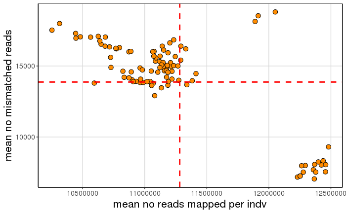

```r
# calculate 25% and 75% percentile for mismatched and total mapped reads
MismatchDist <- unname(quantile(mapstats$MisMatched, 0.25))
MappedDist <- unname(quantile(mapstats$SUM_Mapped, 0.75))
# find point bottom right
ggplot(mapstats, aes(x = SUM_Mapped, y = MisMatched, group = 1)) +
  geom_point(shape = 21, size = 3, color = "black", fill = "darkorange") +
  geom_hline(aes(yintercept = c(MismatchDist)),
             color = "red", linetype = "dashed", size = 1) +
  geom_vline(aes(xintercept = c(MappedDist)),
             color = "red", linetype = "dashed", size = 1) +
  labs(x = "mean no reads mapped per indv",
       y = "mean no mismatched reads") +
  theme_facet
```

Choosing cut-off values for K1 and K2 are a trade-off between maximizing the number of reads in the reference and the number of reads mapped while minimizing the number of reads that are not mapped as a pair.

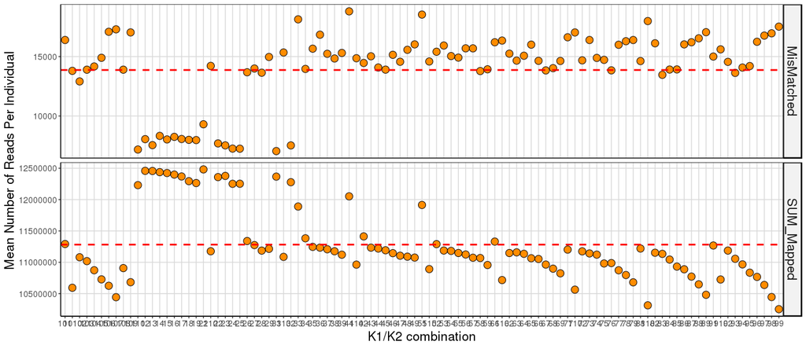

```r
# create tidy data set for plotting
mapstats_tidy <- mapstats %>%
  select(K1, K2, REF, Contigs, MisMatched, SUM_Mapped) %>%
  gather("MAP_STAT", "READS", MisMatched:SUM_Mapped)
# calculate 25% and 75% percentile for mismatched and total mapped reads
MEAN_MISMATCH25 <- unname(quantile(mapstats$MisMatched, 0.25))
READSMAPPED75 <- unname(quantile(mapstats$SUM_Mapped, 0.75))
LOCI50 <- unname(quantile(mapstats$Contigs, c(0.5, .75)))
Percentile <- data.frame(MAP_STAT = c('MisMatched','SUM_Mapped'),
                      yint = with(mapstats_tidy,
                                  c(MEAN_MISMATCH25, READSMAPPED75)))
# plot indicating lowest & highest 25%
ggplot(mapstats_tidy, aes(x = REF, y = READS)) +
  geom_point(shape = 21, size = 4, color = "black", fill = "darkorange") +
  geom_hline(data = Percentile, aes(yintercept = yint),
             color = "red", linetype = "dashed", size = 1) +
  facet_grid(MAP_STAT ~ ., scales = "free") +
  labs(x = "K1/K2 combination",
       y = "Mean Number of Reads Per Individual") +
  theme_facet
```

Reference below the dashed line (25th percentile) for mean number of mismatched paired reads and above the red dashed line (75th percentile) of mean number of reads mapped.

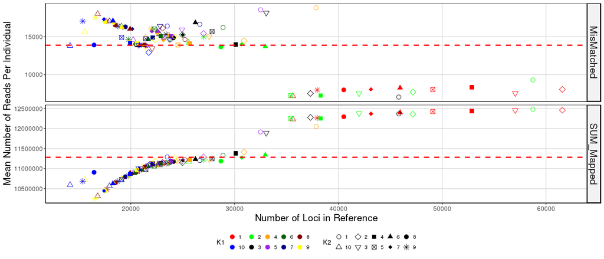

```r
# plot indicating 50 and 75% for number of loci in reference
mapstats_tidy$K1 <- as.character(mapstats_tidy$K1)
mapstats_tidy$K2 <- as.character(mapstats_tidy$K2)
ggplot(mapstats_tidy, aes(x = Contigs, y = READS, color = K1, shape = K2)) +
  geom_point(size = 3) +
  geom_hline(data = Percentile, aes(yintercept = yint),
             color = "red", linetype = "dashed", size = 1) +
  scale_color_manual(values = c("red", "blue", "green", "black", "orange",
                                "purple", "darkgreen", "darkblue", "darkred", "yellow")) +
  scale_shape_manual(values = c(1, 2, 5, 6, 15, 7, 17, 18, 19, 8)) +
  facet_grid(MAP_STAT ~ ., scales = "free") +
  labs(x = "Number of Loci in Reference",
       y = "Mean Number of Reads Per Individual") +
  theme_facet
```

### Assemble references for K1/K2 combinations

Write bash script to create a new directory for each reference to be generated, here for K1 = 1-6 and K2 = 1-10.

```r
K1 <- as.character(c(1:6))
K2 <- as.character(c(1:10))

path <- "/home/soleary/BULLSHARKS/CLE_POPGEN/data/REF/"
command <- "mkdir"

REF <- expand.grid(K1, K2) %>%
  mutate(temp = "REF",
         PATH = path,
         COMMAND = command) %>%
  select(COMMAND, PATH, temp, Var1, Var2) %>%
  unite(dir, 2:4, sep = "", remove = TRUE) %>%
  arrange(dir) %>%
  unite(PATH, 2:3, remove = TRUE)

write_delim(REF, "scr/mkdirREF.sh", col_names = FALSE)
```

Run bash script to write new directories:

```bash
chmod 755 scr/mkdirREF.sh
./scr/mkdirREF.sh
```

In each Reference directory create soft links to the demultiplexed (and quality trimmed) fastq files from the REF library (possible to cut and paste all commands at once or create a bash script to execute).

```r
miseq <- "/home/soleary/BULLSHARKS/CLE_POPGEN/data/SEQ/CLE-1/*.fq.gz"

command <- "ln -s"

SEQ <- REF %>%
  select(PATH) %>%
  mutate(COMMAND = command,
         SEQ = miseq) %>%
  select(COMMAND, SEQ, PATH)

write.table(SEQ, "scr/miseq_softlinks.sh",
            col.names = FALSE, quote = FALSE, row.names = FALSE)
```

Create softlinks in each folder:

```bash
chmod 755 scr/miseq_softlinks.sh
./scr/miseq_softlinks.sh
```

Write configuration files for dDocent:

Within each `REF*`-directory, execute `dDocent` to initiate a run which will create a reference for the chosen c-value and K1/K2 data cut-offs.

```bash
cd /home/soleary/BULLSHARKS/CLE_POPGEN/data/REF/REF1_1

cd /home/soleary/BULLSHARKS/CLE_POPGEN/data/REF/REF2_1

cd /home/soleary/BULLSHARKS/CLE_POPGEN/data/REF/REF3_1

cd /home/soleary/BULLSHARKS/CLE_POPGEN/data/REF/REF4_1
```

```
$ dDocent

# follow text prompts
Number of Processors: ##
Trimming? no
Assembly? yes
Type_of_Assembly? OL
Clustering_Similarity%: 0.8
Map reads? no
Email?
```

Remove the softlinks to the MiSeq data used for mapping and other files generated during `dDocent`-run in each folder, so that only `reference.fasta` and associated files and stats files remain:

```r
# number of references generated
n <- 60

# create vector with n elements
files <- as.character(c(1:n))

# create dataframe with file names to be removed
files <- data.frame(files) %>%
  mutate(F1 = "*.fq.gz",
         F2 = "*.seqs",
         F3 = "*.fastq",
         F4 = "*.gz",
         F5 = "namelist",
         F6 = "uniqCperindv",
         F7 = "dDocent.runs") %>%
  select(-files)

# create combined dataframe of all ref directories and files to be removed
command <- "rm"

RM <- bind_cols(REF, files) %>%
  select(-COMMAND) %>%
  gather(key = temp, value = FILE, 2:8) %>%
  select(-temp) %>%
  unite(col = PATH, 1:2, sep = "/", remove = TRUE) %>%
  mutate(COMMAND = command) %>%
  select(COMMAND, PATH)

write.table(RM, "scr/remove-miseq.sh",
            col.names = FALSE, quote = FALSE, row.names = FALSE)
```

Remove unnecessary intermediate files

```bash
chmod 755 scr/remove-miseq.sh
./scr/remove-miseq.sh
```

K1 and K2 are chosen based on mapping statistics of mapping HiSeq data to MiSeq data, i.e. HiSeq data needs to be demultiplexed and quality trimmed before it can be mapped. In each Reference directory create links to the demultiplexed fastq files for 20 individuals. The set of individuals should include individuals from as many locations as possible.

```r
# path to directory with untrimmed fastq files for 20 individuals
hiseq <- "/home/soleary/BULLSHARKS/CLE_POPGEN/data/SEQ/REFtest/*.fq.gz"

command <- "ln -s"

# create dataframe to create softlinks in each reference directory
SEQ <- REF %>%
  select(PATH) %>%
  mutate(COMMAND = command,
         SEQ = hiseq) %>%
  select(COMMAND, SEQ, PATH)

# write script to file
write.table(SEQ, "scr/hiseq_softlinks.sh",
            col.names = FALSE, quote = FALSE, row.names = FALSE)
```

Write softlinks to hiseq sequence data for 20 individuals:

```bash
chmod 755 scr/hiseq_softlinks.sh
./scr/hiseq_softlinks.sh
```

Write configuration file to run dDocent in each reference directory.

```r
# Number of Processors
processors <- "25"
# Maximum Memory
memory <- "0"
# Trimming
trim <- "yes"
# Assembly?
assembly <- "no"
# Type_of_Assembly
assembly_type <- "PE"
# Clustering_Similarity%
c <- 0.8
# Mapping_Reads?
map <- "yes"
# Mapping_Match_Value
match <- "1"
# Mapping_MisMatch_Value
mismatch <- "3"
# Mapping_GapOpen_Penalty
gap_pen <- "5"
# Calling_SNPs?
callSNPs <- "yes"
# Email
email <- "shannon.j.oleary@gmail.com"

# write configuration file
config <- as.data.frame(c("Number of Processors", processors, "Maximum Memory", memory, "Trimming", trim, "Assembly?", assembly, "Type_of_Assembly", assembly_type, "Clustering_Similarity%", c, "Mapping_Reads?", map, "Mapping_Match_Value", match, "Mapping_MisMatch_Value", mismatch, "Mapping_GapOpen_Penalty",gap_pen, "Calling_SNPs?", callSNPs, "Email", email))

# write configuration file to file
write.table(config, "scr/dDocent_maphiseq.config",
            col.names = FALSE, quote = FALSE, row.names = FALSE)

# write script to place copy of configuration file in each reference directory
config <- "/home/soleary/BULLSHARKS/CLE_POPGEN/scr/dDocent_maphiseq.config"

command <- "cp"

# create dataframe to create softlinks in each reference directory
CP <- REF %>%
  mutate(COMMAND = command,
         FILE = config) %>%
  select(COMMAND, FILE, PATH)

# write script to file
write.table(CP, "scr/copy_config.sh",
            col.names = FALSE, quote = FALSE, row.names = FALSE)
```

Copy configuration file into each reference directory:

```bash
chmod 755 scr/copy_config.sh
./scr/copy_config.sh
```

Execute `dDocent` from within each reference folder to initiate a run to map those individuals to the generated references and call SNPs.

```r
command <- "cd"

df <- REF %>%
  mutate(COMMAND = command,
         temp = c(1:nrow(REF)),
         dDOCENT = "dDocent dDocent_maphiseq.config")

df1 <- df %>%
  select(temp, dDOCENT) %>%
  rename(col1 = dDOCENT)

df2 <- df %>%
  select(temp, COMMAND, PATH) %>%
  unite(col1, COMMAND, PATH, sep = " ", remove = TRUE)

MAP <- bind_rows(df2, df1) %>%
           arrange(temp) %>%
  select(-temp)

# write script to file
write.table(MAP, "scr/map-hiseq.sh",
            col.names = FALSE, quote = FALSE, row.names = FALSE)
```

Run dDocent on each reference to map reads and call SNPs.

```bash
chmod 755 scr/map-hiseq.sh
./scr/map-hiseq.sh
```

Write file to remove softlinks to hiseq sequence files.

```r
command <- "rm"

RM <- REF %>%
  mutate(COMMAND = command,
         FASTQ = "*.fq.gz") %>%
  unite(FILE, PATH, FASTQ, sep = "/", remove = TRUE)

# write script to file
write.table(RM, "scr/rm-hiseq.sh",
            col.names = FALSE, quote = FALSE, row.names = FALSE)
```

Remove fastq files.

```bash
chmod 755 scr/rm-hiseq.sh
./scr/rm-hiseq.sh
```

### Query mapping statistics

During the mapping stage, `dDocent` calls `BWA` to map reads from the individuals in the folder to the generated MiSeqReference and create a `-RG.bam`-file for each individual. The second column of a BAM (or SAM) file contains FLAGs with binary encoded information on mapping, pairedness etc. that can be used to compare the mapping efficiency of the generated MiSeq references.

Count number of reads and mapped reads using `samtools idxstats <aln-RG.bam>` which will retrieve and print stats in the bam-file. The output is TAB-delimited with each line consisting of reference sequence name, sequence length, # mapped reads and # unmapped (empty) reads. `samtools` can also be be used to query `samtools flagstat file.bam` which returns an output containing the number of reads for which each flag is true.

#### Run Flagstats

```bash
cd /home/soleary/BULLSHARKS/CLE_POPGEN/data/SEQ/REFtest

ls -lh >> test.ind
```

Write script to gather flagstats from all `bam`-files.

```r
bam <- read.table("data/SEQ/REFtest/test.ind",
                  header = FALSE, skip = 1, stringsAsFactors = FALSE) %>%
  filter(!V9 == "test.ind") %>%
  separate(V9, into = c("IND", "temp"), -9) %>%
  mutate(FILE = "-RG.bam") %>%
  unite(BAM, IND, FILE, sep = "") %>%
  select(BAM) %>%
  distinct()

bam <- as.data.frame(t(bam)) %>%
  mutate(COMMAND = "samtools flagstat",
         OUT = ">> REF.flagstats") %>%
  gather(key = IND, value = FILE, 1:20) %>%
  select(COMMAND, FILE, OUT)

write.table(bam, "scr/flagstats.sh",
            col.names = FALSE, quote = FALSE, row.names = FALSE)

# write script to place copy of configuration file in each reference directory
scr <- "/home/soleary/BULLSHARKS/CLE_POPGEN/scr/flagstats.sh"

command <- "cp"

# create dataframe to create softlinks in each reference directory
CP <- REF %>%
  mutate(COMMAND = command,
         FILE = scr) %>%
  select(COMMAND, FILE, PATH)

# write script to file
write.table(CP, "scr/copy_flagstats.sh",
            col.names = FALSE, quote = FALSE, row.names = FALSE)
```

Copy flagstats.

```bash
chmod 755 scr/copy_flagstats.sh
./scr/copy_flagstats.sh
```

Create script to run flagstats for all references.

```r
command <- "cd"

df <- REF %>%
  mutate(COMMAND = command,
         temp = c(1:nrow(REF)),
         CHMOD = "chmod 755 flagstats.sh",
         EXECUTE = "./flagstats.sh")

df1 <- df %>%
  select(temp, CHMOD) %>%
  rename(col1 = CHMOD)

df2 <- df %>%
  select(temp, EXECUTE) %>%
  rename(col1 = EXECUTE)

df3 <- df %>%
  select(temp, COMMAND, PATH) %>%
  unite(col1, COMMAND, PATH, sep = " ", remove = TRUE)

FLAG <- bind_rows(df3, df1)

FLAG <- bind_rows(FLAG, df2) %>%
           arrange(temp) %>%
  select(-temp)

# write script to file
write.table(FLAG, "scr/run_flagstats.sh",
            col.names = FALSE, quote = FALSE, row.names = FALSE)
```

Run flagstats.

```bash
chmod 755 scr/run_flagstats.sh
./scr/run_flagstats.sh
```

Need to rename and copy into results folder.

```r
K1 <- as.character(c(1:6))
K2 <- as.character(c(1:10))

rename <- expand.grid(K1, K2) %>%
  mutate(temp = "REF",
         ending = ".flagstats") %>%
  select(temp, Var1, Var2, ending) %>%
  unite(REF, 1:4, sep = "") %>%
  arrange(REF) %>%
  mutate(mv = "mv REF.flagstats",
         temp = c(1:60)) %>%
  select(temp, mv, REF) %>%
  unite(col1, mv, REF, sep = " ")

# View(rename)

command <- "cd"

df <- REF %>%
  mutate(COMMAND = command,
         temp = c(1:nrow(REF)),
         MV = "mv *.flagstats /home/soleary/BULLSHARKS/CLE_POPGEN/results/")

df1 <- df %>%
  select(temp, COMMAND, PATH) %>%
  unite(col1, COMMAND, PATH, sep = " ", remove = TRUE)

df2 <- df %>%
  select(temp, MV) %>%
  rename(col1 = MV)

MV <- bind_rows(df1, rename)

MV <- bind_rows(MV, df2) %>%
           arrange(temp) %>%
  select(-temp)

# View(MV)

# write script to file
write.table(MV, "scr/move_flagstats.sh",
            col.names = FALSE, quote = FALSE, row.names = FALSE)
```

Execute:

```bash
chmod 755 scr/move_flagstats.sh
./scr/move_flagstats.sh
```

##### Run idxstats

Write script to gather idxstats from all `bam`-files.

```r
bam <- read.table("data/SEQ/REFtest/test.ind",
                  header = FALSE, skip = 1, stringsAsFactors = FALSE) %>%
  filter(!V9 == "test.ind") %>%
  separate(V9, into = c("IND", "temp"), -9) %>%
  mutate(FILE = "-RG.bam") %>%
  unite(BAM, IND, FILE, sep = "") %>%
  select(BAM) %>%
  distinct()

bam <- as.data.frame(t(bam)) %>%
  mutate(COMMAND = "samtools idxstats",
         OUT = ">> REF.idxstats") %>%
  gather(key = IND, value = FILE, 1:20) %>%
  select(COMMAND, FILE, OUT)

write.table(bam, "scr/idxstats.sh",
            col.names = FALSE, quote = FALSE, row.names = FALSE)

# write script to place copy of configuration file in each reference directory
scr <- "/home/soleary/BULLSHARKS/CLE_POPGEN/scr/idxstats.sh"

command <- "cp"

# create dataframe to create softlinks in each reference directory
CP <- REF %>%
  mutate(COMMAND = command,
         FILE = scr) %>%
  select(COMMAND, FILE, PATH)

# write script to file
write.table(CP, "scr/copy_idxstats.sh",
            col.names = FALSE, quote = FALSE, row.names = FALSE)
```

Copy idxstats.

```bash
chmod 755 scr/copy_idxstats.sh
./scr/copy_idxstats.sh
```

Create script to run idxstats for all references.

```r
command <- "cd"

df <- REF %>%
  mutate(COMMAND = command,
         temp = c(1:nrow(REF)),
         CHMOD = "chmod 755 idxstats.sh",
         EXECUTE = "./idxstats.sh")

df1 <- df %>%
  select(temp, CHMOD) %>%
  rename(col1 = CHMOD)

df2 <- df %>%
  select(temp, EXECUTE) %>%
  rename(col1 = EXECUTE)

df3 <- df %>%
  select(temp, COMMAND, PATH) %>%
  unite(col1, COMMAND, PATH, sep = " ", remove = TRUE)

FLAG <- bind_rows(df3, df1)

FLAG <- bind_rows(FLAG, df2) %>%
           arrange(temp) %>%
  select(-temp)

# write script to file
write.table(FLAG, "scr/run_idxstats.sh",
            col.names = FALSE, quote = FALSE, row.names = FALSE)
```

Run idxstats.

```bash
chmod 755 scr/run_idxstats.sh
./scr/run_idxstats.sh
```

Need to rename and copy into results folder.

```r
K1 <- as.character(c(1:6))
K2 <- as.character(c(1:10))

rename <- expand.grid(K1, K2) %>%
  mutate(temp = "REF",
         ending = ".idxstats") %>%
  select(temp, Var1, Var2, ending) %>%
  unite(REF, 1:4, sep = "") %>%
  arrange(REF) %>%
  mutate(mv = "mv REF.idxstats",
         temp = c(1:60)) %>%
  select(temp, mv, REF) %>%
  unite(col1, mv, REF, sep = " ")

View(rename)

command <- "cd"

df <- REF %>%
  mutate(COMMAND = command,
         temp = c(1:nrow(REF)),
         MV = "mv *.idxstats /home/soleary/BULLSHARKS/CLE_POPGEN/results/")

df1 <- df %>%
  select(temp, COMMAND, PATH) %>%
  unite(col1, COMMAND, PATH, sep = " ", remove = TRUE)

df2 <- df %>%
  select(temp, MV) %>%
  rename(col1 = MV)

MV <- bind_rows(df1, rename)

MV <- bind_rows(MV, df2) %>%
           arrange(temp) %>%
  select(-temp)

View(MV)

# write script to file
write.table(MV, "scr/move_idxstats.sh",
            col.names = FALSE, quote = FALSE, row.names = FALSE)
```

Execute:

```bash
chmod 755 scr/move_idxstats.sh
./scr/move_idxstats.sh
```

#### Format stats files into tidy data sets

Appending the file results in the information per individual being printed in a new set of row being appended to the file, i.e. there will be as many rows for a given locus as individuals were mapped. The file can be re-formatted and summary statistics calculated using dplyr and tidyr.

Format idxstats

```r
# having max value for K2 = 10 causing problems (2 digits); need to manually edit
# create vectors of files to be imported, reference codes, K1 and K2, dataframe names
filenames <- list.files(path = "results", pattern = "*.idxstats")
ref_code <- substr(filenames, 4, 5)
ref_code <- c("11", "110", "12", "13", "14", "15", "16", "17", "18", "19", "21", "210", "22", "23", "24", "25", "26", "27", "28", "29", "31", "310", "32", "33", "34", "35", "36", "37", "38", "39", "41", "410", "42", "43", "44", "45", "46", "47", "48", "49", "51", "510", "52", "53", "54", "55", "56", "57", "58", "59", "61", "610", "62", "63", "64", "65", "66", "67", "68", "69")
k1_list <- substr(filenames, 4, 4)
k2_list <- substr(filenames, 5, 5)
k2_list <- c("1", "10", "2", "3", "4", "5", "6", "7", "8", "9", "1", "10", "2", "3", "4", "5", "6", "7", "8", "9", "1", "10", "2", "3", "4", "5", "6", "7", "8", "9", "1", "10", "2", "3", "4", "5", "6", "7", "8", "9", "1", "10", "2", "3", "4", "5", "6", "7", "8", "9", "1", "10", "2", "3", "4", "5", "6", "7", "8", "9")
names <- substr(filenames, 1, 9)
names <- c("REF11.idx", "REF110.idx", "REF12.idx", "REF13.idx", "REF14.idx", "REF15.idx", "REF16.idx", "REF17.idx", "REF18.idx", "REF19.idx", "REF21.idx", "REF210.idx", "REF22.idx",
"REF23.idx", "REF24.idx", "REF25.idx", "REF26.idx", "REF27.idx", "REF28.idx", "REF29.idx", "REF31.idx", "REF310.idx", "REF32.idx", "REF33.idx", "REF34.idx", "REF35.idx",
"REF36.idx", "REF37.idx", "REF38.idx", "REF39.idx", "REF41.idx", "REF410.idx", "REF42.idx", "REF43.idx", "REF44.idx", "REF45.idx", "REF46.idx", "REF47.idx", "REF48.idx",
"REF49.idx", "REF51.idx", "REF510.idx", "REF52.idx", "REF53.idx", "REF54.idx", "REF55.idx", "REF56.idx", "REF57.idx", "REF58.idx", "REF59.idx", "REF61.idx", "REF610.idx",
"REF62.idx", "REF63.idx", "REF64.idx", "REF65.idx", "REF66.idx", "REF67.idx", "REF68.idx", "REF69.idx")
# import data
for (i in names){
  filepath <- file.path("results", paste(i, 'stats', sep =""))
  assign(i, read.table(filepath, sep = "", header = FALSE,
                     col.names = c("Locus", "Length", "Reads_Mapped", 'blank')) %>%
           select(1:3))
  }
# Create list of one dataframe per idxstats file and group by locus
# make sure to delete old list if rerunning the code
dflist_idx <- lapply(ls(pattern = "*.idx"), get)
# dflist_idx <- dflist_idx[-1]
for (df in 1:length(dflist_idx)){
  x <- dflist_idx[[df]]
  x[['Locus']] <- as.character(x[['Locus']])
  x = x %>% group_by(Locus)
  dflist_idx[[df]] <- x
}
# Create new dataframes with summary stats per REF bind into final output/dataframe
RefMapStats.idx <- data.frame()
for (df in 1:length(dflist_idx)){
  x = summarize(dflist_idx[[df]],
                Length = mean(Length),
                Mean_Mapped = mean(Reads_Mapped),
                Sum_Mapped = sum(Reads_Mapped),
                Min_Mapped = min(Reads_Mapped),
                Max_Mapped = max(Reads_Mapped),
                SD_Mapped = sd(Reads_Mapped))
  x[x == 0] <- NA
  temp <- summarize(x, Mean_Mapped_Non0 = mean(Mean_Mapped, na.rm = TRUE)) %>%
    mutate(K1 = k1_list[df],
           K2 = k2_list[df],
           REF = ref_code[df],
           Not_Mapped = nrow(filter(x, is.na(Sum_Mapped))),
           N_Loci_Ref = nrow(x)) %>%
    select(K1, K2, REF, N_Loci_Ref, Not_Mapped, Mean_Mapped_Non0)
  RefMapStats.idx <- bind_rows(RefMapStats.idx, temp)
}
write.table(RefMapStats.idx, "results/RefMapStats.idx", quote = FALSE)
```

Format flagstats

```r
# Files to be imported
filenames <- list.files(path='results', pattern = '*.flagstats')
# create vectors of files to be imported
names <- substr(filenames, 1, 10)
names <- c("REF11.flag", "REF110.flag", "REF12.flag", "REF13.flag", "REF14.flag", "REF15.flag", "REF16.flag", "REF17.flag", "REF18.flag", "REF19.flag", "REF21.flag", "REF210.flag", "REF22.flag",
"REF23.flag", "REF24.flag", "REF25.flag", "REF26.flag", "REF27.flag", "REF28.flag", "REF29.flag", "REF31.flag", "REF310.flag", "REF32.flag", "REF33.flag", "REF34.flag", "REF35.flag",
"REF36.flag", "REF37.flag", "REF38.flag", "REF39.flag", "REF41.flag", "REF410.flag", "REF42.flag", "REF43.flag", "REF44.flag", "REF45.flag", "REF46.flag", "REF47.flag", "REF48.flag",
"REF49.flag", "REF51.flag", "REF510.flag", "REF52.flag", "REF53.flag", "REF54.flag", "REF55.flag", "REF56.flag", "REF57.flag", "REF58.flag", "REF59.flag", "REF61.flag", "REF610.flag",
"REF62.flag", "REF63.flag", "REF64.flag", "REF65.flag", "REF66.flag", "REF67.flag", "REF68.flag", "REF69.flag")
# import data
for (i in names){
  filepath <- file.path('results', paste(i, 'stats', sep =""))
  assign(i, read.csv(filepath, sep = "+", header = FALSE,
                     col.names = c("N_Reads", "CAT"),
                     stringsAsFactors = FALSE) %>%
           select(1:2))
}
rm(dflist_flag)
```

```
object 'dflist_flag' not found
```

```r
# Create list of one dataframe per flagstats file and create tidy data set
# should be 60 - 1 elements/references
dflist_flag <- lapply(ls(pattern = "*flag"), get)
# dflist_flag <- dflist_flag[-1]
# dflist_flag <- dflist_flag[-17]
# Change N_Reads to numeric
for (df in 1:length(dflist_flag)){
  x <- dflist_flag[[df]]
  x[['N_Reads']] <- as.numeric(x[['N_Reads']])
  dflist_flag[[df]] <- x
}
```

[output not shown]

With increasing values for K1 and K2 less contigs have sufficient coverage to be included in the generated reference. Further, each reference will contain a certain portion of loci that no reads are mapped to.

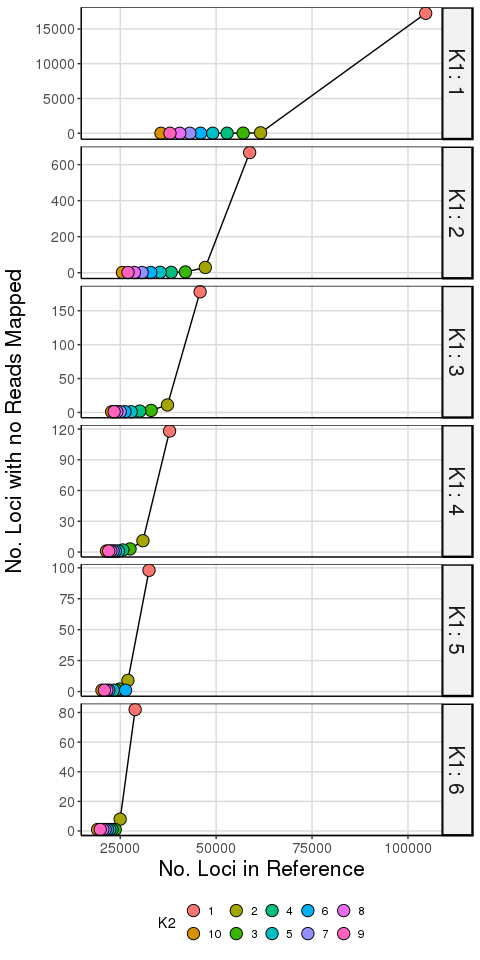

```r
# plot no of loci vs "empty" loci
ggplot(RefMapStats.idx, aes(x = N_Loci_Ref, y = Not_Mapped, fill = K2, group = K1)) +
  geom_line(color = "black") +
  geom_point(shape = 21, size = 4, color = "black") +
  facet_grid(K1 ~ ., labeller = label_both, scales = "free") +
  labs(x = "No. Loci in Reference", y = "No. Loci with no Reads Mapped") +
  theme_facet
```

The mean number of reads mapped to each locus will increase for increasingly high cut-off values.

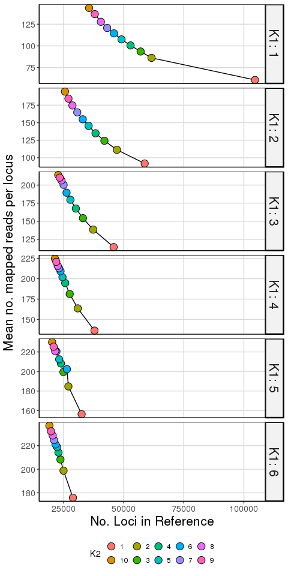

```r
# plot no of loci vs coverage
ggplot(RefMapStats.idx, aes(x = N_Loci_Ref, y = Mean_Mapped_Non0, fill = K2, group = K1)) +
  geom_line(color = "black") +
  geom_point(shape = 21, size = 4, color = "black") +
  facet_grid(K1 ~ ., labeller = label_both, scales = "free") +
  labs(x = "No. Loci in Reference", y = "Mean no. mapped reads per locus") +
  theme_facet
```

### Evaluate & compare mapping results

Number of loci in the reference and the mean number of reads mapped per individual decrease for increasingly high cut-off values.

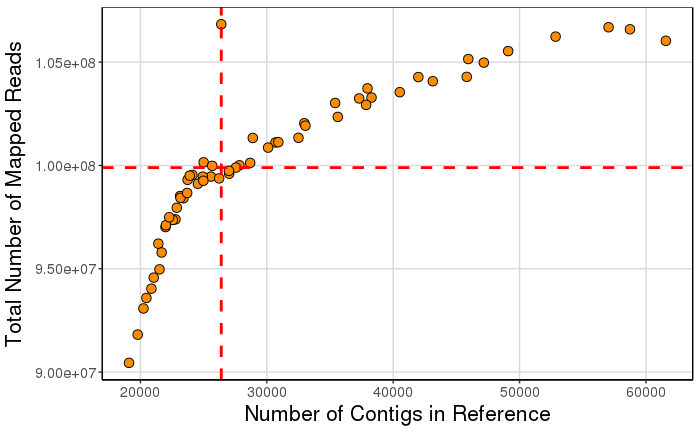

Cut-off values for K1 and K2 should be chosen to maximize the number of reads mapped to the reference and minimize the the number of reads not mapped as a proper pair.

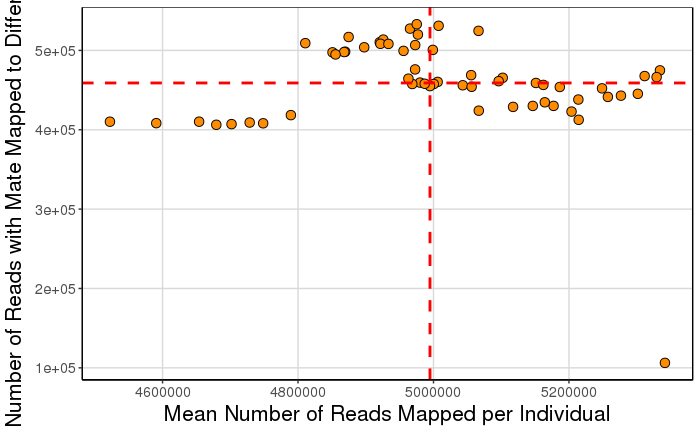

```r
# calculate 25% and 75% percentile for mismatched and total mapped reads
MismatchDist <- unname(quantile(RefMapStats$Mean_Mismatch, 0.5))
MappedDist <- unname(quantile(RefMapStats$Reads_Mapped, 0.5))
# find point bottom right
ggplot(RefMapStats, aes(x = Reads_Mapped, y = Mean_Mismatch, group = 1)) +
  geom_point(shape = 21, size = 3, color = "black", fill = "darkorange") +
  geom_hline(aes(yintercept = c(MismatchDist)),
             color = "red", linetype = "dashed", size = 1) +
  geom_vline(aes(xintercept = c(MappedDist)),
             color = "red", linetype = "dashed", size = 1) +
  labs(x = "Mean Number of Reads Mapped per Individual",
       y = "Mean Number of Reads with Mate Mapped to Different Contig") +
  theme_facet
```

Choosing cut-off values for K1 and K2 are a trade-off between maximizing the number of reads in the reference and the number of reads mapped while minimizing the number of reads that are not mapped as a pair.

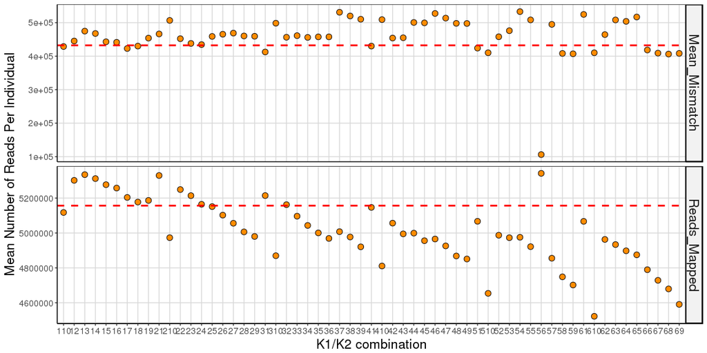

Reference below the dashed line (25th percentile) for mean number of mismatched paired reads and above the red dashed line (75th percentile) of mean number of reads mapped.

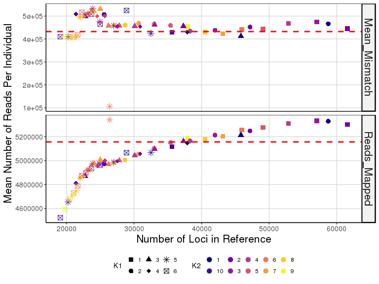

### Query SNP calling stats

Query stats

```bash
# REF11
vcftools --vcf data/REF/REF1_1/TotalRawSNPs.vcf --out data/REF/REF1_1/raw --depth
vcftools --vcf data/REF/REF1_1/TotalRawSNPs.vcf --out data/REF/REF1_1/raw --site-mean-depth
vcftools --vcf data/REF/REF1_1/TotalRawSNPs.vcf --out data/REF/REF1_1/raw --missing-indv
vcftools --vcf data/REF/REF1_1/TotalRawSNPs.vcf --out data/REF/REF1_1/raw --missing-site
vcftools --vcf data/REF/REF1_1/TotalRawSNPs.vcf --out data/REF/REF1_1/raw --site-quality

vcftools --vcf data/REF/REF1_1/TotalRawSNPs.vcf --out data/REF/REF1_1/fil --minQ 20 --mac 3 --minDP 3 --min-meanDP 15 --recode --recode-INFO-all

vcftools --vcf data/REF/REF1_1/fil.recode.vcf --out data/REF/REF1_1/fil --missing-indv
vcftools --vcf data/REF/REF1_1/fil.recode.vcf --out data/REF/REF1_1/fil --missing-site

# REF21
vcftools --vcf data/REF/REF2_1/TotalRawSNPs.vcf --out data/REF/REF2_1/raw --depth
vcftools --vcf data/REF/REF2_1/TotalRawSNPs.vcf --out data/REF/REF2_1/raw --site-mean-depth
vcftools --vcf data/REF/REF2_1/TotalRawSNPs.vcf --out data/REF/REF2_1/raw --missing-indv
vcftools --vcf data/REF/REF2_1/TotalRawSNPs.vcf --out data/REF/REF2_1/raw --missing-site
vcftools --vcf data/REF/REF2_1/TotalRawSNPs.vcf --out data/REF/REF2_1/raw --site-quality

vcftools --vcf data/REF/REF2_1/TotalRawSNPs.vcf --out data/REF/REF2_1/fil --minQ 20 --mac 3 --minDP 3 --min-meanDP 15 --recode --recode-INFO-all

vcftools --vcf data/REF/REF2_1/fil.recode.vcf --out data/REF/REF2_1/fil --missing-indv
vcftools --vcf data/REF/REF2_1/fil.recode.vcf --out data/REF/REF2_1/fil --missing-site

# REF31
vcftools --vcf data/REF/REF3_1/TotalRawSNPs.vcf --out data/REF/REF3_1/raw --depth
vcftools --vcf data/REF/REF3_1/TotalRawSNPs.vcf --out data/REF/REF3_1/raw --site-mean-depth
vcftools --vcf data/REF/REF3_1/TotalRawSNPs.vcf --out data/REF/REF3_1/raw --missing-indv
vcftools --vcf data/REF/REF3_1/TotalRawSNPs.vcf --out data/REF/REF3_1/raw --missing-site
vcftools --vcf data/REF/REF3_1/TotalRawSNPs.vcf --out data/REF/REF3_1/raw --site-quality

vcftools --vcf data/REF/REF3_1/TotalRawSNPs.vcf --out data/REF/REF3_1/fil --minQ 20 --mac 3 --minDP 3 --min-meanDP 15 --recode --recode-INFO-all

vcftools --vcf data/REF/REF3_1/fil.recode.vcf --out data/REF/REF3_1/fil --missing-indv
vcftools --vcf data/REF/REF3_1/fil.recode.vcf --out data/REF/REF3_1/fil --missing-site

# REF41
vcftools --vcf data/REF/REF4_1/TotalRawSNPs.vcf --out data/REF/REF4_1/raw --depth
vcftools --vcf data/REF/REF4_1/TotalRawSNPs.vcf --out data/REF/REF4_1/raw --site-mean-depth
vcftools --vcf data/REF/REF4_1/TotalRawSNPs.vcf --out data/REF/REF4_1/raw --missing-indv
vcftools --vcf data/REF/REF4_1/TotalRawSNPs.vcf --out data/REF/REF4_1/raw --missing-site
vcftools --vcf data/REF/REF4_1/TotalRawSNPs.vcf --out data/REF/REF4_1/raw --site-quality

vcftools --vcf data/REF/REF4_1/TotalRawSNPs.vcf --out data/REF/REF4_1/fil --minQ 20 --mac 3 --minDP 3 --min-meanDP 15 --recode --recode-INFO-all

vcftools --vcf data/REF/REF4_1/fil.recode.vcf --out data/REF/REF4_1/fil --missing-indv
vcftools --vcf data/REF/REF4_1/fil.recode.vcf --out data/REF/REF4_1/fil --missing-site

# REF12
vcftools --vcf data/REF/REF1_2/TotalRawSNPs.vcf --out data/REF/REF1_2/raw --depth
vcftools --vcf data/REF/REF1_2/TotalRawSNPs.vcf --out data/REF/REF1_2/raw --site-mean-depth
vcftools --vcf data/REF/REF1_2/TotalRawSNPs.vcf --out data/REF/REF1_2/raw --missing-indv
vcftools --vcf data/REF/REF1_2/TotalRawSNPs.vcf --out data/REF/REF1_2/raw --missing-site
vcftools --vcf data/REF/REF1_2/TotalRawSNPs.vcf --out data/REF/REF1_2/raw --site-quality

vcftools --vcf data/REF/REF1_2/TotalRawSNPs.vcf --out data/REF/REF1_2/fil --minQ 20 --mac 3 --minDP 3 --min-meanDP 15 --recode --recode-INFO-all

vcftools --vcf data/REF/REF1_2/fil.recode.vcf --out data/REF/REF1_2/fil --missing-indv
vcftools --vcf data/REF/REF1_2/fil.recode.vcf --out data/REF/REF1_2/fil --missing-site

# REF22
vcftools --vcf data/REF/REF2_2/TotalRawSNPs.vcf --out data/REF/REF2_2/raw --depth
vcftools --vcf data/REF/REF2_2/TotalRawSNPs.vcf --out data/REF/REF2_2/raw --site-mean-depth
vcftools --vcf data/REF/REF2_2/TotalRawSNPs.vcf --out data/REF/REF2_2/raw --missing-indv
vcftools --vcf data/REF/REF2_2/TotalRawSNPs.vcf --out data/REF/REF2_2/raw --missing-site
vcftools --vcf data/REF/REF2_2/TotalRawSNPs.vcf --out data/REF/REF2_2/raw --site-quality

vcftools --vcf data/REF/REF2_2/TotalRawSNPs.vcf --out data/REF/REF2_2/fil --minQ 20 --mac 3 --minDP 3 --min-meanDP 15 --recode --recode-INFO-all

vcftools --vcf data/REF/REF2_2/fil.recode.vcf --out data/REF/REF2_2/fil --missing-indv
vcftools --vcf data/REF/REF2_2/fil.recode.vcf --out data/REF/REF2_2/fil --missing-site

# REF32
vcftools --vcf data/REF/REF3_2/TotalRawSNPs.vcf --out data/REF/REF3_2/raw --depth
vcftools --vcf data/REF/REF3_2/TotalRawSNPs.vcf --out data/REF/REF3_2/raw --site-mean-depth
vcftools --vcf data/REF/REF3_2/TotalRawSNPs.vcf --out data/REF/REF3_2/raw --missing-indv
vcftools --vcf data/REF/REF3_2/TotalRawSNPs.vcf --out data/REF/REF3_2/raw --missing-site
vcftools --vcf data/REF/REF3_2/TotalRawSNPs.vcf --out data/REF/REF3_2/raw --site-quality

vcftools --vcf data/REF/REF3_2/TotalRawSNPs.vcf --out data/REF/REF3_2/fil --minQ 20 --mac 3 --minDP 3 --min-meanDP 15 --recode --recode-INFO-all

vcftools --vcf data/REF/REF3_2/fil.recode.vcf --out data/REF/REF3_2/fil --missing-indv
vcftools --vcf data/REF/REF3_2/fil.recode.vcf --out data/REF/REF3_2/fil --missing-site

# REF42
vcftools --vcf data/REF/REF4_2/TotalRawSNPs.vcf --out data/REF/REF4_2/raw --depth
vcftools --vcf data/REF/REF4_2/TotalRawSNPs.vcf --out data/REF/REF4_2/raw --site-mean-depth
vcftools --vcf data/REF/REF4_2/TotalRawSNPs.vcf --out data/REF/REF4_2/raw --missing-indv
vcftools --vcf data/REF/REF4_2/TotalRawSNPs.vcf --out data/REF/REF4_2/raw --missing-site
vcftools --vcf data/REF/REF4_2/TotalRawSNPs.vcf --out data/REF/REF4_2/raw --site-quality

vcftools --vcf data/REF/REF4_2/TotalRawSNPs.vcf --out data/REF/REF4_2/fil --minQ 20 --mac 3 --minDP 3 --min-meanDP 15 --recode --recode-INFO-all

vcftools --vcf data/REF/REF4_2/fil.recode.vcf --out data/REF/REF4_2/fil --missing-indv
vcftools --vcf data/REF/REF4_2/fil.recode.vcf --out data/REF/REF4_2/fil --missing-site

# REF56
vcftools --vcf data/REF/REF5_6/TotalRawSNPs.vcf --out data/REF/REF5_6/raw --depth
vcftools --vcf data/REF/REF5_6/TotalRawSNPs.vcf --out data/REF/REF5_6/raw --site-mean-depth
vcftools --vcf data/REF/REF5_6/TotalRawSNPs.vcf --out data/REF/REF5_6/raw --missing-indv
vcftools --vcf data/REF/REF5_6/TotalRawSNPs.vcf --out data/REF/REF5_6/raw --missing-site
vcftools --vcf data/REF/REF5_6/TotalRawSNPs.vcf --out data/REF/REF5_6/raw --site-quality

vcftools --vcf data/REF/REF5_6/TotalRawSNPs.vcf --out data/REF/REF5_6/fil --minQ 20 --mac 3 --minDP 3 --min-meanDP 15 --recode --recode-INFO-all

vcftools --vcf data/REF/REF5_6/fil.recode.vcf --out data/REF/REF5_6/fil --missing-indv
vcftools --vcf data/REF/REF5_6/fil.recode.vcf --out data/REF/REF5_6/fil --missing-site
```

### Evaluate SNP data sets

Missing data

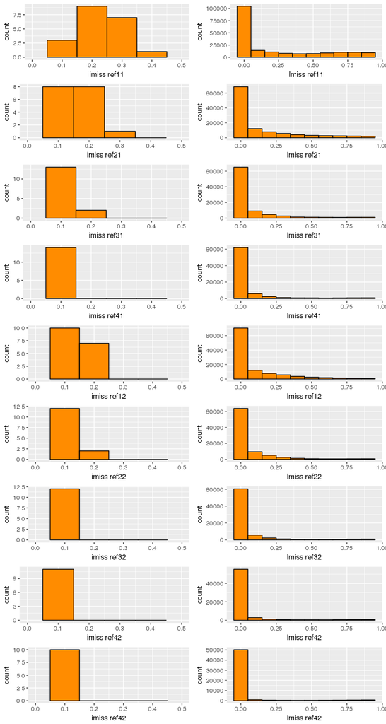

Missing data after filtering

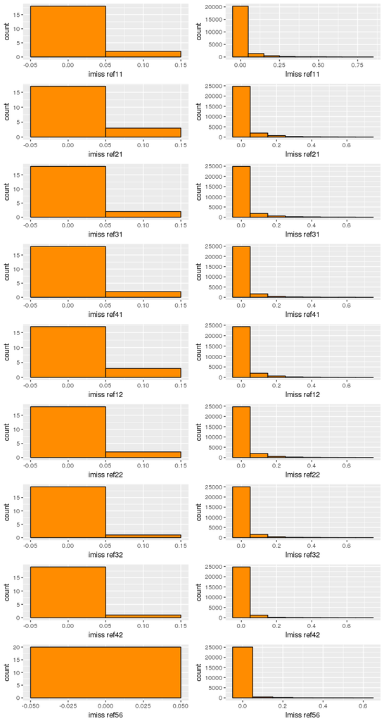

```r
p1 <- read.table("data/REF/REF1_1/fil.imiss",
           header = TRUE, stringsAsFactors = FALSE) %>%
  ggplot() +
  geom_histogram(aes(x = F_MISS),
                 binwidth = 0.1, fill = "darkorange", color = "black") +
  labs(x = "imiss ref11")
p10 <- read.table("data/REF/REF1_1/fil.lmiss",
           header = TRUE, stringsAsFactors = FALSE) %>%
  ggplot() +
  geom_histogram(aes(x = F_MISS),
                 binwidth = 0.1, fill = "darkorange", color = "black") +
  labs(x = "lmiss ref11")
p2 <- read.table("data/REF/REF2_1/fil.imiss",
           header = TRUE, stringsAsFactors = FALSE) %>%
  ggplot() +
  geom_histogram(aes(x = F_MISS),
                 binwidth = 0.1, fill = "darkorange", color = "black") +
  labs(x = "imiss ref21")
p11 <- read.table("data/REF/REF2_1/fil.lmiss",
           header = TRUE, stringsAsFactors = FALSE) %>%
  ggplot() +
  geom_histogram(aes(x = F_MISS),
                 binwidth = 0.1, fill = "darkorange", color = "black") +
  labs(x = "lmiss ref21")
p3 <- read.table("data/REF/REF3_1/fil.imiss",
           header = TRUE, stringsAsFactors = FALSE) %>%
  ggplot() +
  geom_histogram(aes(x = F_MISS),
                 binwidth = 0.1, fill = "darkorange", color = "black") +
  labs(x = "imiss ref31")
p12 <- read.table("data/REF/REF3_1/fil.lmiss",
           header = TRUE, stringsAsFactors = FALSE) %>%
  ggplot() +
  geom_histogram(aes(x = F_MISS),
                 binwidth = 0.1, fill = "darkorange", color = "black") +
  labs(x = "lmiss ref31")
p4 <- read.table("data/REF/REF4_1/fil.imiss",
           header = TRUE, stringsAsFactors = FALSE) %>%
  ggplot() +
  geom_histogram(aes(x = F_MISS),
                 binwidth = 0.1, fill = "darkorange", color = "black") +
  labs(x = "imiss ref41")
p13 <- read.table("data/REF/REF4_1/fil.lmiss",
           header = TRUE, stringsAsFactors = FALSE) %>%
  ggplot() +
  geom_histogram(aes(x = F_MISS),
                 binwidth = 0.1, fill = "darkorange", color = "black") +
  labs(x = "lmiss ref41")
p5 <- read.table("data/REF/REF1_2/fil.imiss",
           header = TRUE, stringsAsFactors = FALSE) %>%
  ggplot() +
  geom_histogram(aes(x = F_MISS),
                 binwidth = 0.1, fill = "darkorange", color = "black") +
  labs(x = "imiss ref12")
p14 <- read.table("data/REF/REF1_2/fil.lmiss",
           header = TRUE, stringsAsFactors = FALSE) %>%
  ggplot() +
  geom_histogram(aes(x = F_MISS),
                 binwidth = 0.1, fill = "darkorange", color = "black") +
  labs(x = "lmiss ref12")
p6 <- read.table("data/REF/REF2_2/fil.imiss",
           header = TRUE, stringsAsFactors = FALSE) %>%
  ggplot() +
  geom_histogram(aes(x = F_MISS),
                 binwidth = 0.1, fill = "darkorange", color = "black") +
  labs(x = "imiss ref22")
p15 <- read.table("data/REF/REF2_2/fil.lmiss",
           header = TRUE, stringsAsFactors = FALSE) %>%
  ggplot() +
  geom_histogram(aes(x = F_MISS),
                 binwidth = 0.1, fill = "darkorange", color = "black") +
  labs(x = "lmiss ref22")
p7 <- read.table("data/REF/REF3_2/fil.imiss",
           header = TRUE, stringsAsFactors = FALSE) %>%
  ggplot() +
  geom_histogram(aes(x = F_MISS),
                 binwidth = 0.1, fill = "darkorange", color = "black") +
  labs(x = "imiss ref32")
p16 <- read.table("data/REF/REF3_2/fil.lmiss",
           header = TRUE, stringsAsFactors = FALSE) %>%
  ggplot() +
  geom_histogram(aes(x = F_MISS),
                 binwidth = 0.1, fill = "darkorange", color = "black") +
  labs(x = "lmiss ref32")
p8 <- read.table("data/REF/REF4_2/fil.imiss",
           header = TRUE, stringsAsFactors = FALSE) %>%
  ggplot() +
  geom_histogram(aes(x = F_MISS),
                 binwidth = 0.1, fill = "darkorange", color = "black") +
  labs(x = "imiss ref42")
p17 <- read.table("data/REF/REF4_2/fil.lmiss",
           header = TRUE, stringsAsFactors = FALSE) %>%
  ggplot() +
  geom_histogram(aes(x = F_MISS),
                 binwidth = 0.1, fill = "darkorange", color = "black") +
  labs(x = "lmiss ref42")
p9 <- read.table("data/REF/REF5_6/fil.imiss",
           header = TRUE, stringsAsFactors = FALSE) %>%
  ggplot() +
  geom_histogram(aes(x = F_MISS),
                 binwidth = 0.1, fill = "darkorange", color = "black") +
  labs(x = "imiss ref56")
p18 <- read.table("data/REF/REF5_6/fil.lmiss",
           header = TRUE, stringsAsFactors = FALSE) %>%
  ggplot() +
  geom_histogram(aes(x = F_MISS),
                 binwidth = 0.1, fill = "darkorange", color = "black") +
  labs(x = "lmiss ref56")
multiplot(p1, p2, p3, p4, p5, p6, p7, p8, p9, p10, p11, p12, p13, p14, p15, p16, p17, p18, cols = 2)
```

Depth data (raw)

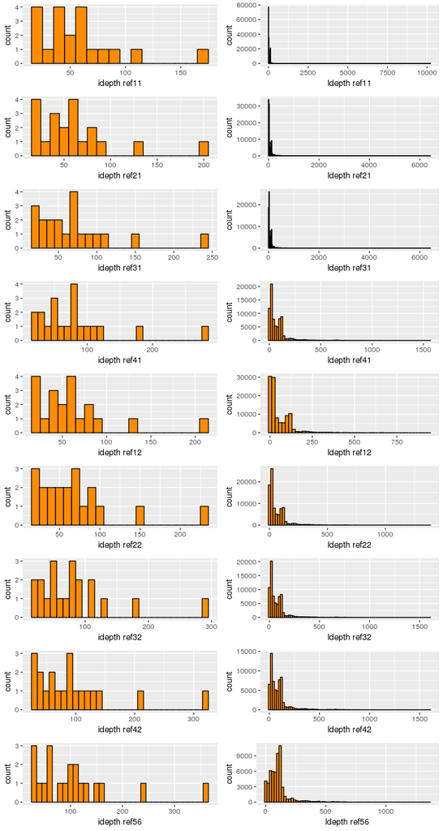

```r
p1 <- read.table("data/REF/REF1_1/raw.idepth",
           header = TRUE, stringsAsFactors = FALSE) %>%
  ggplot() +
  geom_histogram(aes(x = MEAN_DEPTH),
                 binwidth = 10, fill = "darkorange", color = "black") +
  labs(x = "idepth ref11")
p10 <- read.table("data/REF/REF1_1/raw.ldepth.mean",
           header = TRUE, stringsAsFactors = FALSE) %>%
  ggplot() +
  geom_histogram(aes(x = MEAN_DEPTH),
                 binwidth = 20, fill = "darkorange", color = "black") +
  labs(x = "ldepth ref11")
p2 <- read.table("data/REF/REF2_1/raw.idepth",
           header = TRUE, stringsAsFactors = FALSE) %>%
  ggplot() +
  geom_histogram(aes(x = MEAN_DEPTH),
                 binwidth = 10, fill = "darkorange", color = "black") +
  labs(x = "idepth ref21")
p11 <- read.table("data/REF/REF2_1/raw.ldepth.mean",
           header = TRUE, stringsAsFactors = FALSE) %>%
  ggplot() +
  geom_histogram(aes(x = MEAN_DEPTH),
                 binwidth = 20, fill = "darkorange", color = "black") +
  labs(x = "ldepth ref21")
p3 <- read.table("data/REF/REF3_1/raw.idepth",
           header = TRUE, stringsAsFactors = FALSE) %>%
  ggplot() +
  geom_histogram(aes(x = MEAN_DEPTH),
                 binwidth = 10, fill = "darkorange", color = "black") +
  labs(x = "idepth ref31")
p12 <- read.table("data/REF/REF3_1/raw.ldepth.mean",
           header = TRUE, stringsAsFactors = FALSE) %>%
  ggplot() +
  geom_histogram(aes(x = MEAN_DEPTH),
                 binwidth = 20, fill = "darkorange", color = "black") +
  labs(x = "ldepth ref31")
p4 <- read.table("data/REF/REF4_1/raw.idepth",
           header = TRUE, stringsAsFactors = FALSE) %>%
  ggplot() +
  geom_histogram(aes(x = MEAN_DEPTH),
                 binwidth = 10, fill = "darkorange", color = "black") +
  labs(x = "idepth ref41")
p13 <- read.table("data/REF/REF4_1/raw.ldepth.mean",
           header = TRUE, stringsAsFactors = FALSE) %>%
  ggplot() +
  geom_histogram(aes(x = MEAN_DEPTH),
                 binwidth = 20, fill = "darkorange", color = "black") +
  labs(x = "ldepth ref41")
p5 <- read.table("data/REF/REF1_2/raw.idepth",
           header = TRUE, stringsAsFactors = FALSE) %>%
  ggplot() +
  geom_histogram(aes(x = MEAN_DEPTH),
                 binwidth = 10, fill = "darkorange", color = "black") +
  labs(x = "idepth ref12")
p14 <- read.table("data/REF/REF1_2/raw.ldepth.mean",
           header = TRUE, stringsAsFactors = FALSE) %>%
  ggplot() +
  geom_histogram(aes(x = MEAN_DEPTH),
                 binwidth = 20, fill = "darkorange", color = "black") +
  labs(x = "ldepth ref12")
p6 <- read.table("data/REF/REF2_2/raw.idepth",
           header = TRUE, stringsAsFactors = FALSE) %>%
  ggplot() +
  geom_histogram(aes(x = MEAN_DEPTH),
                 binwidth = 10, fill = "darkorange", color = "black") +
  labs(x = "idepth ref22")
p15 <- read.table("data/REF/REF2_2/raw.ldepth.mean",
           header = TRUE, stringsAsFactors = FALSE) %>%
  ggplot() +
  geom_histogram(aes(x = MEAN_DEPTH),
                 binwidth = 20, fill = "darkorange", color = "black") +
  labs(x = "ldepth ref22")
p7 <- read.table("data/REF/REF3_2/raw.idepth",
           header = TRUE, stringsAsFactors = FALSE) %>%
  ggplot() +
  geom_histogram(aes(x = MEAN_DEPTH),
                 binwidth = 10, fill = "darkorange", color = "black") +
  labs(x = "idepth ref32")
p16 <- read.table("data/REF/REF3_2/raw.ldepth.mean",
           header = TRUE, stringsAsFactors = FALSE) %>%
  ggplot() +
  geom_histogram(aes(x = MEAN_DEPTH),
                 binwidth = 20, fill = "darkorange", color = "black") +
  labs(x = "ldepth ref32")
p8 <- read.table("data/REF/REF4_2/raw.idepth",
           header = TRUE, stringsAsFactors = FALSE) %>%
  ggplot() +
  geom_histogram(aes(x = MEAN_DEPTH),
                 binwidth = 10, fill = "darkorange", color = "black") +
  labs(x = "idepth ref42")
p17 <- read.table("data/REF/REF4_2/raw.ldepth.mean",
           header = TRUE, stringsAsFactors = FALSE) %>%
  ggplot() +
  geom_histogram(aes(x = MEAN_DEPTH),
                 binwidth = 20, fill = "darkorange", color = "black") +
  labs(x = "ldepth ref42")
p9 <- read.table("data/REF/REF5_6/raw.idepth",
           header = TRUE, stringsAsFactors = FALSE) %>%
  ggplot() +
  geom_histogram(aes(x = MEAN_DEPTH),
                 binwidth = 10, fill = "darkorange", color = "black") +
  labs(x = "idepth ref56")
p18 <- read.table("data/REF/REF5_6/raw.ldepth.mean",
           header = TRUE, stringsAsFactors = FALSE) %>%
  ggplot() +
  geom_histogram(aes(x = MEAN_DEPTH),
                 binwidth = 20, fill = "darkorange", color = "black") +
  labs(x = "ldepth ref56")
multiplot(p1, p2, p3, p4, p5, p6, p7, p8, p9, p10, p11, p12, p13, p14, p15, p16, p17, p18, cols = 2)
```

SNP call quality

```r
lqual <- read.table("data/REF/REF1_1/raw.lqual",
                    header = TRUE, stringsAsFactors = FALSE)

count(lqual, QUAL > 20)

# 35%

lqual <- read.table("data/REF/REF2_1/raw.lqual",
                    header = TRUE, stringsAsFactors = FALSE)

count(lqual, QUAL > 20)

# 32%


lqual <- read.table("data/REF/REF4_4/raw.lqual",
                    header = TRUE, stringsAsFactors = FALSE)

count(lqual, QUAL > 20)

# 25%
```

# Finalize *de nov* reference cut-offs:

Values chosen for MiSeq Reference:

- **c** = 0.8
- **K1** = 5
- **K2** = 6